# Tesla stocks and news sentiment correlation

Zinkevich Oleg

March 2021

# Используемая литература

- P. Hofmarcher, S. Theussl, and K. Hornik, Do Media Sentiments Reflect Economic Indices? Chinese Business Review. 2011, 10(7): 487-492. // http://www.davidpublisher.com/Public/uploads/Contribute/55629146c962b.pdf
- Kalyani Joshi, Bharathi H. N., Jyothi Rao, STOCK TREND PREDICTION USING NEWS SENTIMENT ANALYSIS // https://arxiv.org/ftp/arxiv/papers/1607/1607.01958.pdf
- R. Goonatilake and S. Herath, The volatility of the stock market and news, International Research Journal of Finance and Economics, 2007, 11: 53-65 // https://citeseerx.ist.psu.edu/viewdoc/download?doi=10.1.1.124.5376&rep=rep1&type=pdf
- Kalyani Joshi, Bharathi H. N., Jyothi Rao, STOCK TREND PREDICTION USING NEWS SENTIMENT ANALYSIS https://arxiv.org/ftp/arxiv/papers/1607/1607.01958.pdf

# Используемые данные

- Tesla (TSLA) stock prices dataset from 2010 till 2020.
- 2.7 mln news articles from 2013 to early 2020 from 27 American publications https://components.one/datasets/all-the-news-2-news-articles-dataset/

### Произведен предварительный импорт 8gb csv датасета с помощью библиотеки data.table, а также фильтрация заголовков статей по ключевым словам “musk|tesla”

# Подготовка отфильтрованных данных

```r
library(tidyverse)
library(tidytext)
library(glue)
library(stringr)
library(syuzhet)
library(ggplot2)
library(SnowballC)
library(tm)
library(wordcloud)
library(lubridate)
library(ggplot2)
library(data.table)
library(DT)
library(psych)
library(plotly)
library(ggpubr)
library(onewaytests)

datatable_options = list(dom="t", initComplete = JS(
    "function(settings, json) {",
    "$(this.api().table().header()).css({'background-color': '#575757', 'color': '#fff'});",
    "}"))

df <- read_csv('C:/Users/olegz/Dropbox/My/BrandAspect/R_project/final_tesla_news_dataset_date_corrected.csv')

# drop unnecessary columns
df <- df %>% select(-c(X1_1))

DT::datatable(df[1:5,], options = datatable_options, class="cell-border stripe")
```

|  | X1 | title | publication | date_time |
| --- | --- | --- | --- | --- |
| 1 | 1 | Tesla may be building three more Gigafactories | Vox | 2017-02-22 |
| 2 | 2 | A look at Tesla's nine-member board | Reuters | 2018-08-14 |
| 3 | 3 | Tesla delays, tax credit concerns spur sales of Chevy Bolts | Reuters | 2018-02-16 |
| 4 | 4 | Analysts split on Tesla 2019 delivery promises | Reuters | 2019-06-12 |
| 5 | 5 | Tesla's Musk may settle SEC lawsuit but ready for fight: sources | Reuters | 2018-09-28 |

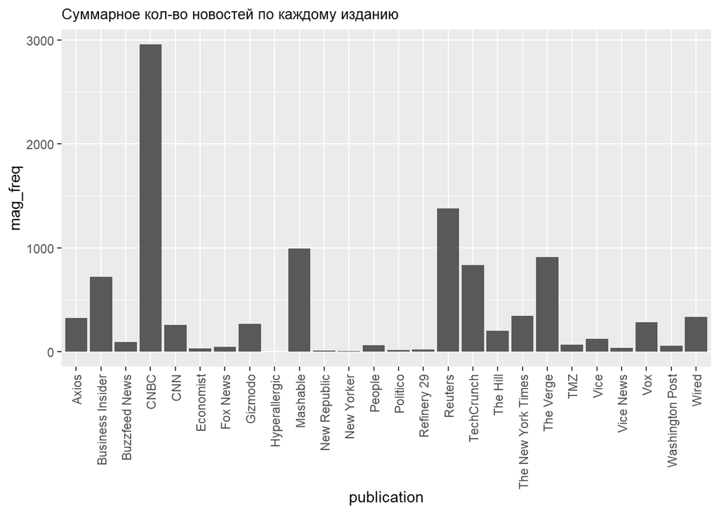

```r
# group stats by magazines
grouped_magazines <- df %>%
  group_by(publication) %>%
  summarize(mag_freq = length(publication))

# bar chart - news count per magazine
bar_chart <- ggplot(data = grouped_magazines, aes(x=publication, y=mag_freq))+
  geom_bar(stat="identity")+
  theme(axis.text.x=element_text(angle=90, hjust=1,vjust=0.5)) +
  ggtitle("Суммарное кол-во новостей по каждому изданию") +
  theme(plot.title = element_text(size=(10)))
bar_chart
```

## Процессинг текстовых данных

```r
# creating text corpus with tm package
corpus <- Corpus(VectorSource(df$title))

preprocess <- function(corpus) {

  corpus <- tm_map(corpus, content_transformer(tolower))
  corpus <- tm_map(corpus, removeNumbers)
  corpus <- tm_map(corpus, removePunctuation)
  corpus <- tm_map(corpus, stripWhitespace)
  corpus <- tm_map(corpus, stemDocument)
  corpus <- tm_map(corpus, removeWords, c(stopwords('english'), "say", "will", "-", "with", "for", "after"))

  warning("Text pre-processing done")
  return(corpus)
}

corpus <- preprocess(corpus)

# term-doc matrix
term_doc <- TermDocumentMatrix(corpus)
term_doc_matrix <- as.matrix(term_doc)
term_doc
```

```
## <<TermDocumentMatrix (terms: 7060, documents: 10347)>>
## Non-/sparse entries: 79681/72970139
## Sparsity           : 100%
## Maximal term length: 23
## Weighting          : term frequency (tf)
```

```r
# sort by value
term_doc_vals <- sort(rowSums(term_doc_matrix), decreasing=TRUE)
term_doc_docs <- data.frame(word=names(term_doc_vals), freq=term_doc_vals)
head(term_doc_docs, 30)
```

```
##                  word freq
## tesla           tesla 7135
## musk             musk 3910
## elon             elon 3581
## model           model 1446
## techcrunch techcrunch  833
## car               car  751
## new               new  532
## autopilot   autopilot  447
## stock           stock  417
## report         report  392
## updat           updat  391
## teslaus       teslaus  386
## make             make  360
## share           share  352
## electr         electr  345
## spacex         spacex  335
## crash           crash  330
## tweet           tweet  323
## plan             plan  318
## muskus         muskus  310
## product       product  310
## china           china  290
## compani       compani  286
## sec               sec  284
## ceo               ceo  242
## take             take  224
## batteri       batteri  223
## call             call  220
## first           first  219
## get               get  217
```

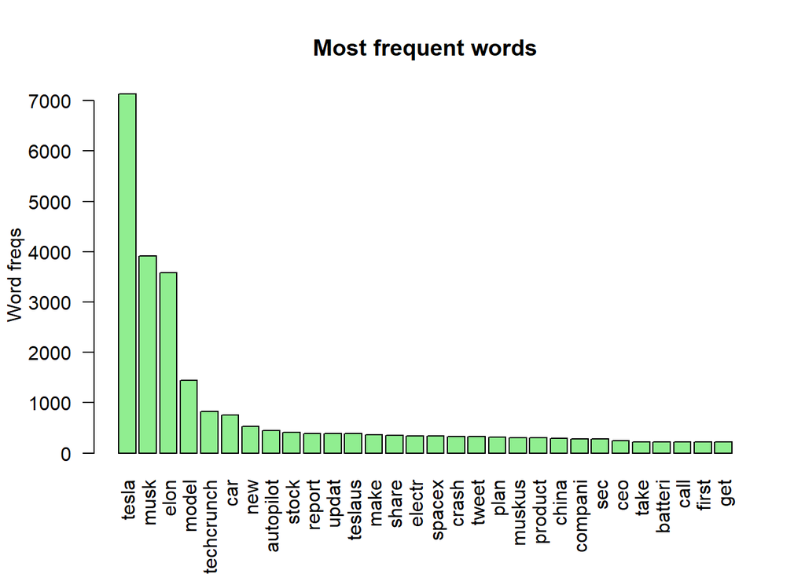

```r
# most frequent words barplot
barplot(term_doc_docs[1:30,]$freq, las = 2, names.arg = term_doc_docs[1:30,]$word,
        col = 'lightgreen', main = "Most frequent words", ylab = 'Word freqs')
```

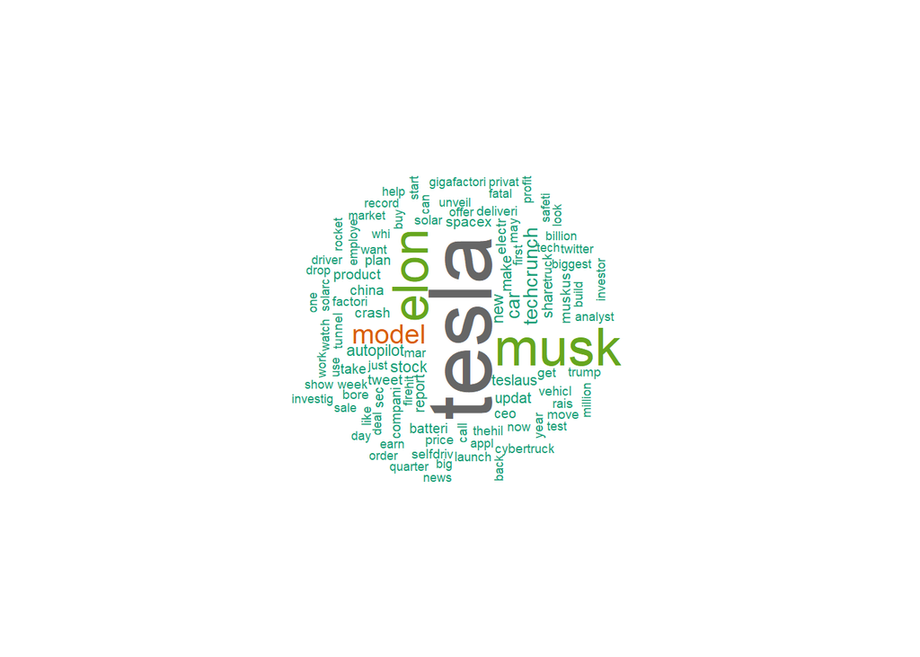

```r
# wordcloud
set.seed(1234)
wordcloud(words=term_doc_docs$word, freq=term_doc_docs$freq, min.freq=5, max.words=100, random.order=FALSE, rot.per=0.35, colors=brewer.pal(8, "Dark2"))
```

## Сентимент анализ новостей

```r
# perform sentiment analysis
news_titles <- df %>%
  # create a new column
  mutate(sentiment_1 = get_sentiment(title, method='syuzhet'))

DT::datatable(news_titles[1:10,], options = datatable_options, class="cell-border stripe")
```

|  | X1 | title | publication | date_time | sentiment_1 |
| --- | --- | --- | --- | --- | --- |
| 1 | 1 | Tesla may be building three more Gigafactories | Vox | 2017-02-22 | 0.1 |
| 2 | 2 | A look at Tesla's nine-member board | Reuters | 2018-08-14 | 0 |
| 3 | 3 | Tesla delays, tax credit concerns spur sales of Chevy Bolts | Reuters | 2018-02-16 | -1.25 |
| 4 | 4 | Analysts split on Tesla 2019 delivery promises | Reuters | 2019-06-12 | 0.6 |
| 5 | 5 | Tesla's Musk may settle SEC lawsuit but ready for fight: sources | Reuters | 2018-09-28 | -0.2 |
| 6 | 6 | Tesla's Elon Musk, SEC ordered by U.S. judge to try to settle | Reuters | 2019-04-04 | 0 |
| 7 | 7 | U.S. Justice Department probes Musk statement on taking Tesla private | Reuters | 2018-09-18 | 1 |
| 8 | 8 | Exclusive: How Tesla's first truck charging stations will be built | Reuters | 2018-02-02 | 0 |
| 9 | 9 | Tesla starts taking Model 3 orders in China | Reuters | 2018-11-16 | 0.4 |
| 10 | 10 | Recode Daily: Elon Musk crashes Tesla&lt;U+0092&gt;s Wall Street beat with a bizarre earnings call | Vox | 2018-05-03 | -1.75 |

## Подсчет среднего дневного значения сентимента для каждой даты

```r
# calculate mean sentiment scores for every date
grouped_sentims <- news_titles %>%
  group_by(date_time) %>%
  summarize(date_avg_sentim = mean(sentiment_1))

DT::datatable(grouped_sentims[1:10,], options = datatable_options, class="cell-border stripe")
```

|  | date_time | date_avg_sentim |
| --- | --- | --- |
| 1 | 2016-01-01 | 0.65 |
| 2 | 2016-01-03 | 0.2 |
| 3 | 2016-01-04 | -0.6 |
| 4 | 2016-01-05 | -0.075 |
| 5 | 2016-01-06 | 0 |
| 6 | 2016-01-09 | 0.12 |
| 7 | 2016-01-10 | 0 |
| 8 | 2016-01-11 | 0.25 |
| 9 | 2016-01-12 | 0.125 |
| 10 | 2016-01-13 | 0 |

## Распределение негативных, позитивных и нейтральных публикаций по изданиям

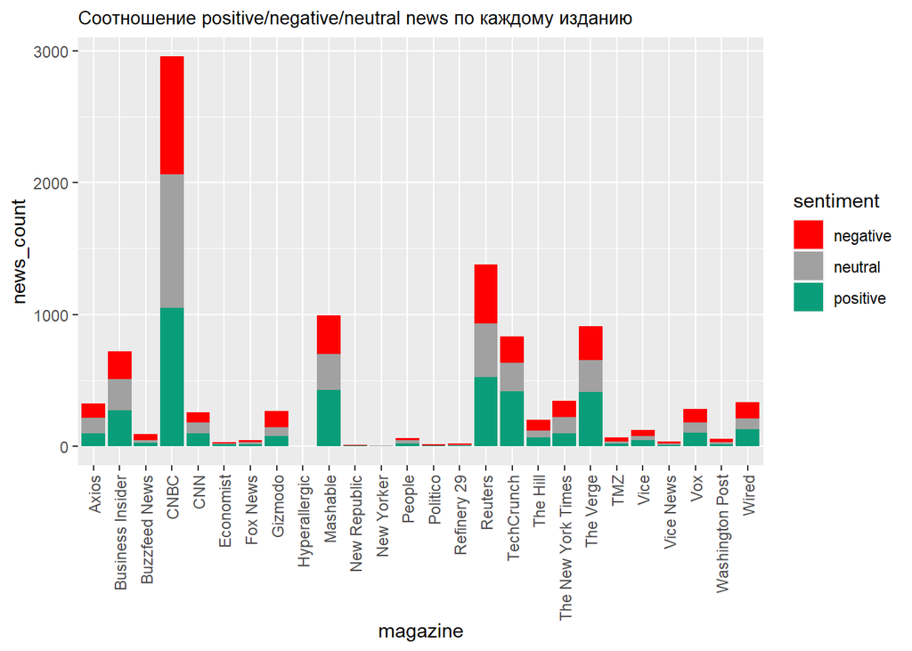

```r
# create datasets with neutral, positive and negative values
news_neg <- news_titles %>%
  filter(sentiment_1 < 0)

news_pos <- news_titles %>%
  filter(sentiment_1 >= 0.2)

news_neutral <- news_titles %>%
  filter(sentiment_1 >= 0, sentiment_1 < 0.2)

grouped_magazines_neg <- news_neg %>%
  group_by(publication) %>%
  summarize(news_count = length(publication)) %>%
  mutate(sentiment = "negative")

grouped_magazines_pos <- news_pos %>%
  group_by(publication) %>%
  summarize(news_count = length(publication)) %>%
  mutate(sentiment = "positive")

grouped_magazines_neu <- news_neutral %>%
  group_by(publication) %>%
  summarize(news_count = length(publication)) %>%
  mutate(sentiment = "neutral")

total <- full_join(grouped_magazines_pos, grouped_magazines_neg)
total <- full_join(total, grouped_magazines_neu)
# rename "publication" column to "magazine"
total <- rename(total, magazine = publication)

bar_chart_total <- ggplot(data = total, aes(x=magazine, y=news_count, fill=sentiment))+
  geom_bar(stat="identity", position = "stack") +
  scale_fill_manual(values = c("#ff0000", "#a1a1a1", "#099e79")) +
  theme(axis.text.x=element_text(angle=90, hjust=1,vjust=0.5)) +
  ggtitle("Соотношение positive/negative/neutral news по каждому изданию") +
  theme(plot.title = element_text(size=(10)))
bar_chart_total
```

## Объединение датасетов - 1. Заголовки новостей и значение сентимента и 2. Стоимость акций Tesla

```r
df_stock <- read_csv('C:/Users/olegz/Dropbox/My/BrandAspect/R_project/TSLA.csv')
# renaming date column to date_time
df_stock <- rename(df_stock, date_time = Date)
df_sent <- grouped_sentims

DT::datatable(df_stock[1:10,], options = datatable_options, class="cell-border stripe")
```

|  | date_time | Open | High | Low | Close | Adj Close | Volume |
| --- | --- | --- | --- | --- | --- | --- | --- |
| 1 | 2010-06-29 | 19 | 25 | 17.540001 | 23.889999 | 23.889999 | 18766300 |
| 2 | 2010-06-30 | 25.790001 | 30.42 | 23.299999 | 23.83 | 23.83 | 17187100 |
| 3 | 2010-07-01 | 25 | 25.92 | 20.27 | 21.959999 | 21.959999 | 8218800 |
| 4 | 2010-07-02 | 23 | 23.1 | 18.709999 | 19.200001 | 19.200001 | 5139800 |
| 5 | 2010-07-06 | 20 | 20 | 15.83 | 16.110001 | 16.110001 | 6866900 |
| 6 | 2010-07-07 | 16.4 | 16.629999 | 14.98 | 15.8 | 15.8 | 6921700 |
| 7 | 2010-07-08 | 16.139999 | 17.52 | 15.57 | 17.459999 | 17.459999 | 7711400 |
| 8 | 2010-07-09 | 17.58 | 17.9 | 16.549999 | 17.4 | 17.4 | 4050600 |
| 9 | 2010-07-12 | 17.950001 | 18.07 | 17 | 17.049999 | 17.049999 | 2202500 |
| 10 | 2010-07-13 | 17.389999 | 18.639999 | 16.9 | 18.139999 | 18.139999 | 2680100 |

```r
# joining by date_time
df_stock <- df_stock %>%
  left_join(df_sent, by = "date_time")

# droping NA news sentim values for missing dates
df_stock_dopped_na <- df_stock %>% drop_na(date_avg_sentim)

# create column with corresponding sentiment
df_stock_dopped_na <- df_stock_dopped_na %>%
  mutate(sentim_str = case_when((df_stock_dopped_na$date_avg_sentim < -0.2) ~ "neg",
                                (df_stock_dopped_na$date_avg_sentim <= 0.2) ~ "neu",
                                (df_stock_dopped_na$date_avg_sentim >= 0.2) ~ "pos"
                   ))
DT::datatable(df_stock_dopped_na[1:10,], options = datatable_options, class="cell-border stripe")
```

|  | date_time | Open | High | Low | Close | Adj Close | Volume | date_avg_sentim | sentim_str |
| --- | --- | --- | --- | --- | --- | --- | --- | --- | --- |
| 1 | 2016-01-04 | 230.720001 | 231.380005 | 219 | 223.410004 | 223.410004 | 6827100 | -0.6 | neg |
| 2 | 2016-01-05 | 226.360001 | 226.889999 | 220 | 223.429993 | 223.429993 | 3186800 | -0.075 | neu |
| 3 | 2016-01-06 | 220 | 220.050003 | 215.979996 | 219.039993 | 219.039993 | 3779100 | 0 | neu |
| 4 | 2016-01-11 | 214.009995 | 214.449997 | 203 | 207.850006 | 207.850006 | 4091400 | 0.25 | pos |
| 5 | 2016-01-12 | 211.600006 | 213.740005 | 205.309998 | 209.970001 | 209.970001 | 3091900 | 0.125 | neu |
| 6 | 2016-01-13 | 212.009995 | 212.649994 | 200 | 200.309998 | 200.309998 | 4126400 | 0 | neu |
| 7 | 2016-01-14 | 202.210007 | 210 | 193.380005 | 206.179993 | 206.179993 | 6490700 | 0.275 | pos |
| 8 | 2016-01-15 | 198.970001 | 205.070007 | 197.25 | 204.990005 | 204.990005 | 5578600 | 0.3 | pos |
| 9 | 2016-01-19 | 208.710007 | 210.470001 | 200.779999 | 204.720001 | 204.720001 | 4038700 | -0.4 | neg |
| 10 | 2016-01-20 | 199.399994 | 201.279999 | 191.25 | 198.699997 | 198.699997 | 5838600 | -0.65 | neg |

# Оценка визуальной корреляции сентимента новостей и стоимости акции

[figure not shown]

```r
# calculate means for stock prices per day per each row
df_stock_mean <- df_stock_dopped_na %>% mutate(
  mean_price = rowMeans(select(., c(Open,High,Low,Close))))

# stats for each 3 sentiments in the dataset
# summarise_stats <- df_stock_mean %>%
  #group_by(sentim_str) %>%
  #summarise(describe(mean_price))

# DT::datatable(summarise_stats, options = datatable_options, class="cell-border stripe")

# filter dataset by time period
means_by_period <- df_stock_mean %>%
  filter(date_time > "2019-01-01" & date_time < "2019-04-01")

# Correlation chart: stock price vs. daily sentiment
correlation_chart <- ggplot() +
  geom_line(mapping = aes(x = means_by_period$date_time, y = means_by_period$Close), size = 1) +
  geom_line(mapping = aes(x = means_by_period$date_time, y = means_by_period$date_avg_sentim*50), size = 0.6, color = "blue") +
  scale_x_date(name = "Date", labels = NULL) +
  scale_y_continuous(name = "Close Stock Price",
                     #Scale 2nd y-axis by factor of 20
                     sec.axis = sec_axis(~./10, name = "Sentiment Score")) +
  theme(
    axis.title.y = element_text(color = "grey"),
    axis.title.y.right = element_text(color = "blue")) +
  ggtitle("Корреляция стоимости акции и сентимента новостей \nВыборка: период 3 месяца: 2019-01-01 - 2019-04-01") +
  theme(plot.title = element_text(size=(10))) +
  geom_vline(xintercept = as.numeric(means_by_period$date_time), linetype=2, colour="#CCCCCC")

correlation_chart
```

# Создание выборок для позитивных и негативных сентиментов и соответствующих показателей стоимости акции

```r
negative_sample <- df_stock_mean %>%
  filter(sentim_str == "neg")

positive_sample <- df_stock_mean %>%
  filter(sentim_str == "pos")
```

# Тест на соответствие выборок нормальному распределению (Shapiro test)

### Проверка гипотезы (H0) - о нормальной распределении данных.

- H0 - данные в популяции распределены нормально.
- H1 - данные не распределены нормально.

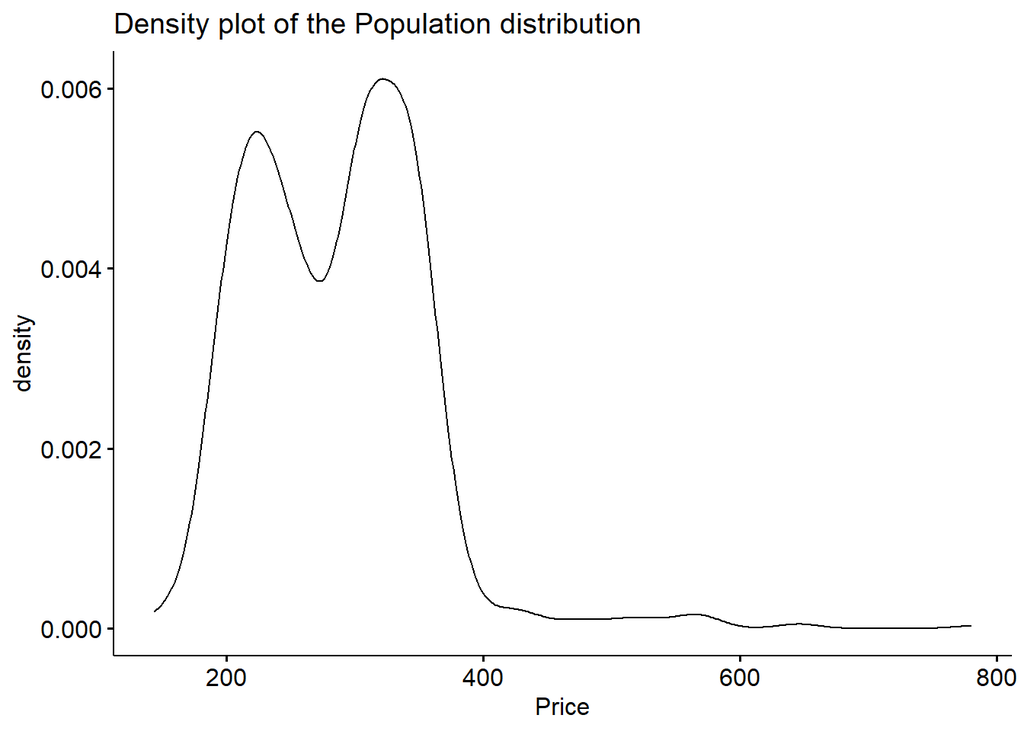

```r
# check for normality of the population.
ggdensity(df_stock_mean$Close,
          main = "Density plot of the Population distribution",
          xlab = "Price")
```

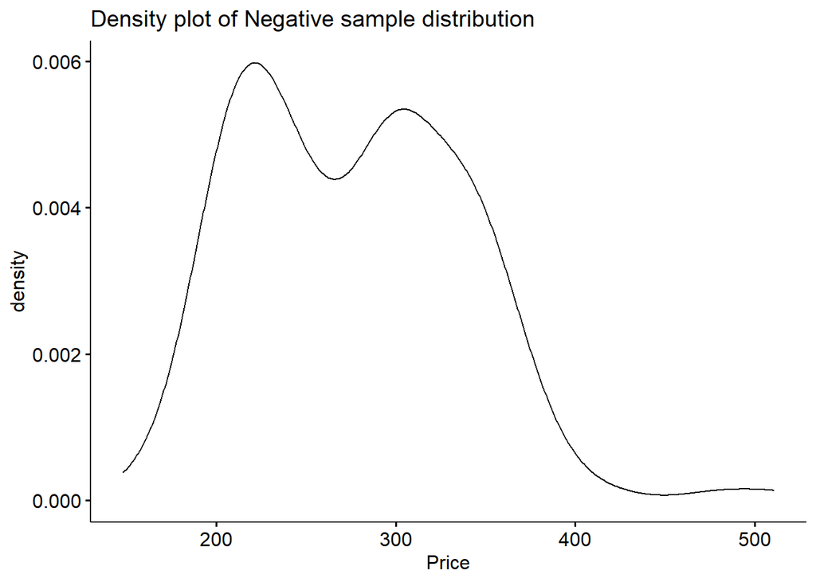

```r
# check for normality of the negative sample
ggdensity(negative_sample$Close,
          main = "Density plot of Negative sample distribution",
          xlab = "Price")
```

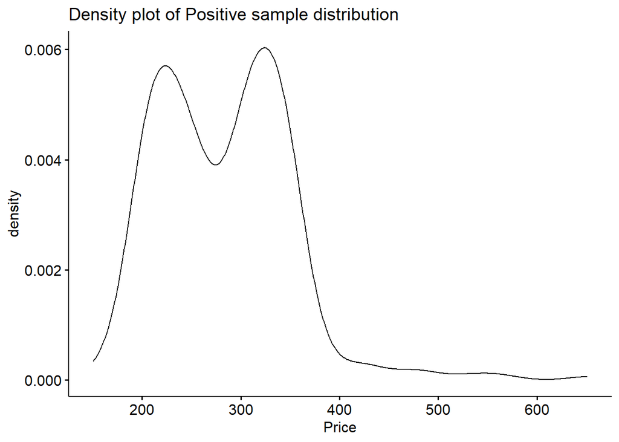

```r
# check for normality of the positive sample
ggdensity(positive_sample$Close,
          main = "Density plot of Positive sample distribution",
          xlab = "Price")
```

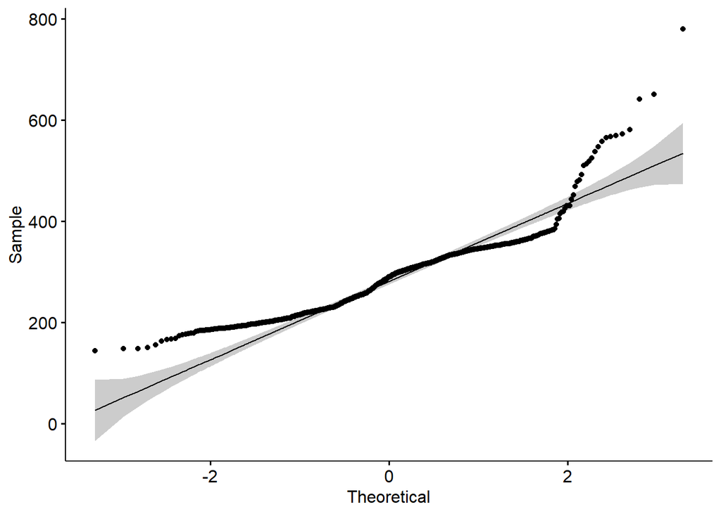

```r
# QQ plot (or quantile-quantile plot) draws the correlation between a given sample and the normal distribution.
ggqqplot(df_stock_mean$Close)
```

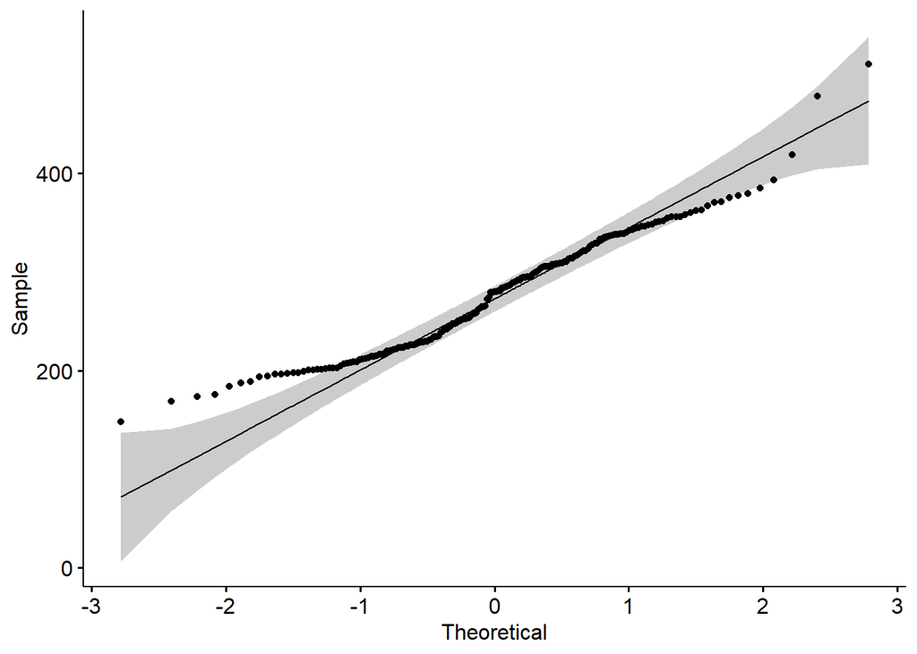

```r
ggqqplot(negative_sample$Close)
```

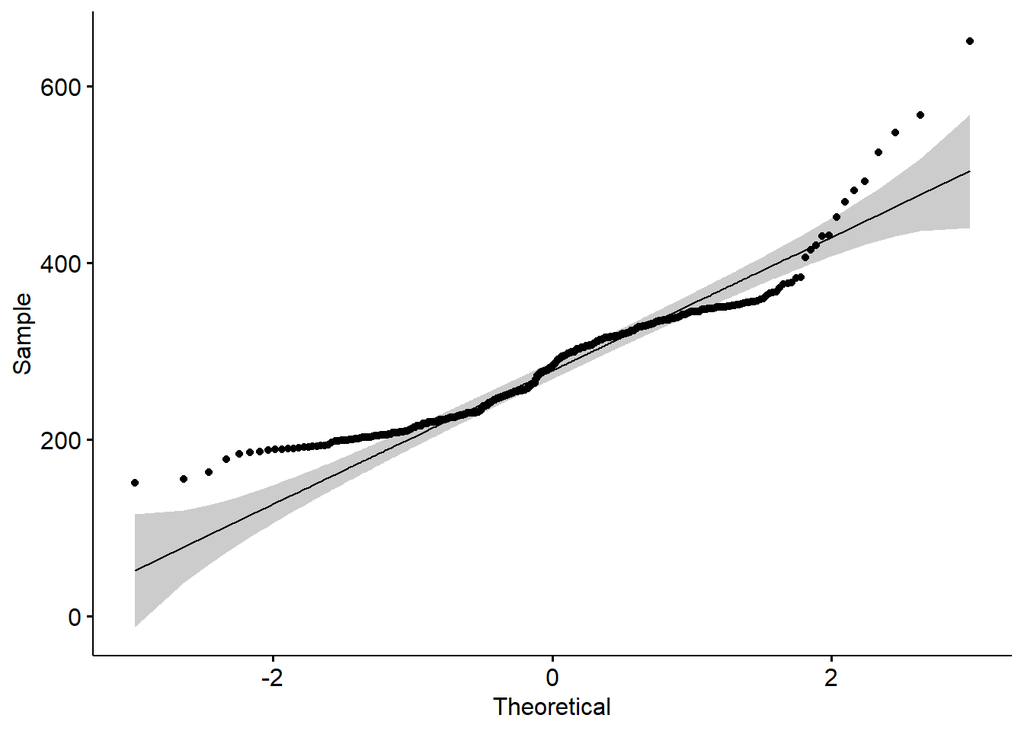

```r
ggqqplot(positive_sample$Close)
```

```r
# Visual inspection, described in the previous section, is usually unreliable. It’s possible to use a significance test comparing the sample distribution to a normal one in order to ascertain whether data show or not a serious deviation from normality.

# There are several methods for normality test such as Kolmogorov-Smirnov (K-S) normality test and Shapiro-Wilk’s test. Shapiro-Wilk’s method is widely recommended for normality test and it provides better power than K-S. It is based on the correlation between the data and the corresponding normal scores
shapiro.test(df_stock_mean$Close)
```

```
##
##  Shapiro-Wilk normality test
##
## data:  df_stock_mean$Close
## W = 0.91372, p-value < 2.2e-16
```

```r
shapiro.test(negative_sample$Close)
```

```
##
##  Shapiro-Wilk normality test
##
## data:  negative_sample$Close
## W = 0.96326, p-value = 8.261e-05
```

```r
# p-value is less than 0.05, (The data is normal if the p-value is above 0.05). So we now know our variable is not normally distributed.
shapiro.test(positive_sample$Close)
```

```
##
##  Shapiro-Wilk normality test
##
## data:  positive_sample$Close
## W = 0.92464, p-value = 1.822e-12
```

```r
# p-value is less than 0.05
```

# Проверка дисперсии (variance test) - для принятия решения о типе используемого теста.

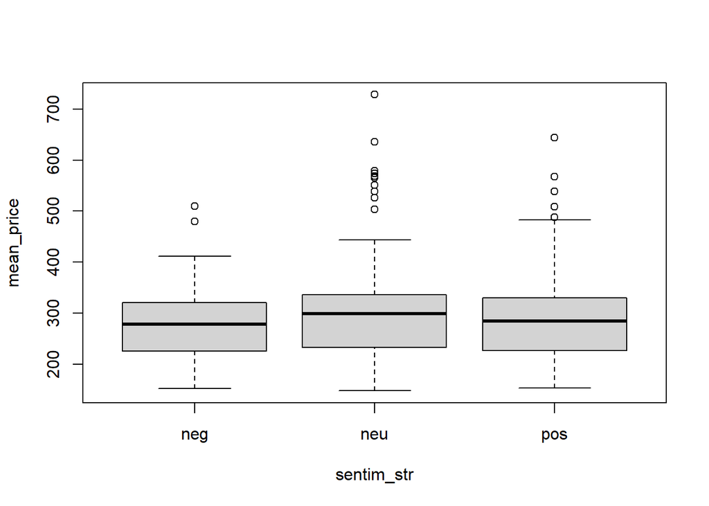

```r
# Samples variance test

# Calculate IQR (межквартильное расстояние)
boxplot(mean_price ~ sentim_str, df_stock_mean)
```

```r
# variance statistics
var(negative_sample$Close)
```

```
## [1] 3797.369
```

```r
var(positive_sample$Close)
```

```
## [1] 4641.902
```

# Тестирование нулевой гипотезы

**1. Wilcoxon-Mann-Whitney**: for non-normal distribution, non‐parametric test for detecting differences between two, or more groups.

```r
wilcox.test(negative_sample$Close, positive_sample$Close, alternative = "less", paired=FALSE)
```

```
##
##  Wilcoxon rank sum test with continuity correction
##
## data:  negative_sample$Close and positive_sample$Close
## W = 31986, p-value = 0.1831
## alternative hypothesis: true location shift is less than 0
```

**p-value = 0.1831**, поэтому мы не можем отказаться от нулевой (H0) гипотезы.

- Welch test - для примера с учетом предположения о Central Limit Theorem. Вопрос - можно ли использовать в данном случае при non-normal distribution?

**2. Welch test**. Welch’s t-test is designed for unequal sample distribution variance, but the assumption of sample distribution normality is maintained.

### H0 - средняя стоимость акции в выборке негативных новостей равна стоимости в позитивной выборке. H1 - средняя стоимость не равна.

```r
two_goups_filtered <- df_stock_mean %>%
  filter(sentim_str == "pos" | sentim_str == "neg")

wt.test(Close ~ sentim_str, data = two_goups_filtered, alpha = 0.05, na.rm = TRUE, verbose = TRUE)
```

```
##
##   Welch's t-Test (alpha = 0.05)
## -------------------------------------------------------------
##   Groups : neg vs. pos
##
##   statistic  : -1.150664
##   parameter  : 411.58
##   p.value    : 0.2505387
##
##   Result     : Difference is not statistically significant.
## -------------------------------------------------------------
```

# Spearman correlation (непараметрический тест) - оценка корреляции стоимости и показателя сентимента.

```r
cor.test(negative_sample$Close, negative_sample$date_avg_sentim, method = "spearman")
```

```
##
##  Spearman's rank correlation rho
##
## data:  negative_sample$Close and negative_sample$date_avg_sentim
## S = 966412, p-value = 0.1228
## alternative hypothesis: true rho is not equal to 0
## sample estimates:
##       rho
## 0.1132502
```

```r
cor.test(positive_sample$Close, positive_sample$date_avg_sentim, method = "spearman")
```

```
##
##  Spearman's rank correlation rho
##
## data:  positive_sample$Close and positive_sample$date_avg_sentim
## S = 8446823, p-value = 0.07107
## alternative hypothesis: true rho is not equal to 0
## sample estimates:
##         rho
## -0.09537967
```

**p-value = 0.07107**

## Выводы

Стоит признать, что подобное исследование требует **системного и многофакторного подхода**, что однако, скорее всего, уменьшит релевантность полученных оценок из-за невозможности непредвзятого суждения о причине и следствии (какие факторы послужили повышению стоимости? Негативная публикация - результат понижения стоимости или ее причина?)

Чтобы судить о взаимозависимости сентимента и стоимости акции нужны поправки на вес издания (с учетом трафика, кол-ва просмотров статьи), импакт фактора новости (кол-во цитирования на сайтах, в блогах, он-лайн изданиях и соц. сетях).